# NYProject

Bhuvana

11/15/2021

This report is being prepared based on tha data that is retrieved from https://data.cityofnewyork.us/api/views/833y-fsy8/rows.csv?accessType=DOWNLOAD on the NY Shooting Incident.

There are mainly information on five boroughs, namely “Queens, Bronx, Manhattan, Staten Island and Brooklyn”, of New York that is collected and an analysis is being done to understand on the Perpetrators who were involved in them, in particular on the females who were involved in each borough

## Importing the Data Set

Data for this Project is being retrieved from here https://data.cityofnewyork.us/api/views/833y-fsy8/rows.csv?accessType=DOWNLOAD

**Initial information that is got is as below.**

```
## # A tibble: 23,585 x 19
##    INCIDENT_KEY OCCUR_DATE OCCUR_TIME BORO     PRECINCT JURISDICTION_CODE
##           <dbl> <chr>      <time>     <chr>       <dbl>             <dbl>
##  1     24050482 08/27/2006 05:35      BRONX          52                 0
##  2     77673979 03/11/2011 12:03      QUEENS        106                 0
##  3    203350417 10/06/2019 01:09      BROOKLYN       77                 0
##  4     80584527 09/04/2011 03:35      BRONX          40                 0
##  5     90843766 05/27/2013 21:16      QUEENS        100                 0
##  6     92393427 09/01/2013 04:17      BROOKLYN       67                 0
##  7     73057167 06/05/2010 21:16      BROOKLYN       77                 0
##  8    211362213 03/20/2020 21:27      BROOKLYN       81                 0
##  9    137564752 07/04/2014 00:25      QUEENS        101                 0
## 10    147024011 10/18/2015 01:33      QUEENS        106                 0
## # ... with 23,575 more rows, and 13 more variables: LOCATION_DESC <chr>,
## #   STATISTICAL_MURDER_FLAG <lgl>, PERP_AGE_GROUP <chr>, PERP_SEX <chr>,
## #   PERP_RACE <chr>, VIC_AGE_GROUP <chr>, VIC_SEX <chr>, VIC_RACE <chr>,
## #   X_COORD_CD <dbl>, Y_COORD_CD <dbl>, Latitude <dbl>, Longitude <dbl>,
## #   Lon_Lat <chr>
```

**A snapshot of the data is as below.**

```
##   INCIDENT_KEY        OCCUR_DATE         OCCUR_TIME           BORO
##  Min.   :  9953245   Length:23585       Length:23585      Length:23585
##  1st Qu.: 55322804   Class :character   Class1:hms        Class :character
##  Median : 83435362   Mode  :character   Class2:difftime   Mode  :character
##  Mean   :102280741                      Mode  :numeric
##  3rd Qu.:150911774
##  Max.   :230611229
##
##     PRECINCT      JURISDICTION_CODE LOCATION_DESC      STATISTICAL_MURDER_FLAG
##  Min.   :  1.00   Min.   :0.000     Length:23585       Mode :logical
##  1st Qu.: 44.00   1st Qu.:0.000     Class :character   FALSE:19085
##  Median : 69.00   Median :0.000     Mode  :character   TRUE :4500
##  Mean   : 66.21   Mean   :0.333
##  3rd Qu.: 81.00   3rd Qu.:0.000
##  Max.   :123.00   Max.   :2.000
##                   NA's   :2
##  PERP_AGE_GROUP       PERP_SEX          PERP_RACE         VIC_AGE_GROUP
##  Length:23585       Length:23585       Length:23585       Length:23585
##  Class :character   Class :character   Class :character   Class :character
##  Mode  :character   Mode  :character   Mode  :character   Mode  :character
##
##
##
##
##    VIC_SEX            VIC_RACE           X_COORD_CD        Y_COORD_CD
##  Length:23585       Length:23585       Min.   : 914928   Min.   :125757
##  Class :character   Class :character   1st Qu.: 999925   1st Qu.:182539
##  Mode  :character   Mode  :character   Median :1007654   Median :193470
##                                        Mean   :1009379   Mean   :207300
##                                        3rd Qu.:1016782   3rd Qu.:239163
##                                        Max.   :1066815   Max.   :271128
##
##     Latitude       Longitude        Lon_Lat
##  Min.   :40.51   Min.   :-74.25   Length:23585
##  1st Qu.:40.67   1st Qu.:-73.94   Class :character
##  Median :40.70   Median :-73.92   Mode  :character
##  Mean   :40.74   Mean   :-73.91
##  3rd Qu.:40.82   3rd Qu.:-73.88
##  Max.   :40.91   Max.   :-73.70
##
```

## Tidying the data

Data is being tidyed by renaming the Column **BORO** to **BOROUGH** and removing the columns OCCUR_TIME, X_COORD_CD, Y_COORD_CD, Lon_Lat, Latitude, Longitude, JURISDICTION_CODE

```
## # A tibble: 23,585 x 12
##    INCIDENT_KEY OCCUR_DATE BOROUGH  PRECINCT LOCATION_DESC STATISTICAL_MURDER_F~
##           <dbl> <chr>      <chr>       <dbl> <chr>         <lgl>
##  1     24050482 08/27/2006 BRONX          52 <NA>          TRUE
##  2     77673979 03/11/2011 QUEENS        106 <NA>          FALSE
##  3    203350417 10/06/2019 BROOKLYN       77 <NA>          FALSE
##  4     80584527 09/04/2011 BRONX          40 <NA>          FALSE
##  5     90843766 05/27/2013 QUEENS        100 <NA>          FALSE
##  6     92393427 09/01/2013 BROOKLYN       67 <NA>          FALSE
##  7     73057167 06/05/2010 BROOKLYN       77 <NA>          FALSE
##  8    211362213 03/20/2020 BROOKLYN       81 <NA>          FALSE
##  9    137564752 07/04/2014 QUEENS        101 <NA>          FALSE
## 10    147024011 10/18/2015 QUEENS        106 <NA>          FALSE
## # ... with 23,575 more rows, and 6 more variables: PERP_AGE_GROUP <chr>,
## #   PERP_SEX <chr>, PERP_RACE <chr>, VIC_AGE_GROUP <chr>, VIC_SEX <chr>,
## #   VIC_RACE <chr>
```

## Transforming the Data

Since we are more interested in knowing about the Perpetrator’s involved, data is being transformed to include only the City , PERP details and VIC details of Age, Sex and Race and STATISTICAL_MURDER_FLAG.

```
## # A tibble: 23,585 x 8
## # Groups:   BOROUGH [5]
##    BOROUGH  PERP_AGE_GROUP PERP_SEX PERP_RACE STATISTICAL_MURDER_~ VIC_AGE_GROUP
##    <chr>    <chr>          <chr>    <chr>     <lgl>                <chr>
##  1 BRONX    <NA>           <NA>     <NA>      TRUE                 25-44
##  2 QUEENS   <NA>           <NA>     <NA>      FALSE                65+
##  3 BROOKLYN <NA>           <NA>     <NA>      FALSE                18-24
##  4 BRONX    <NA>           <NA>     <NA>      FALSE                <18
##  5 QUEENS   <NA>           <NA>     <NA>      FALSE                18-24
##  6 BROOKLYN <NA>           <NA>     <NA>      FALSE                <18
##  7 BROOKLYN <NA>           <NA>     <NA>      FALSE                <18
##  8 BROOKLYN <NA>           <NA>     <NA>      FALSE                25-44
##  9 QUEENS   <NA>           <NA>     <NA>      FALSE                18-24
## 10 QUEENS   <NA>           <NA>     <NA>      FALSE                18-24
## # ... with 23,575 more rows, and 2 more variables: VIC_SEX <chr>,
## #   VIC_RACE <chr>
```

## Visualizing the Data

1. In this first visualization, information about the Perpetrator’s race and the Age Group’s who were involved in is being looked into.

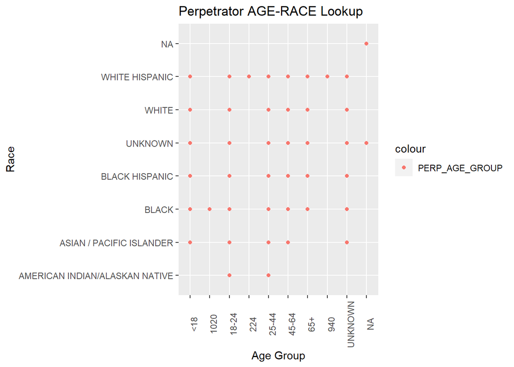

2. In this second visualization, the information with regard to Perpetrator’s race and the Borough, where they are involved in is being looked into.

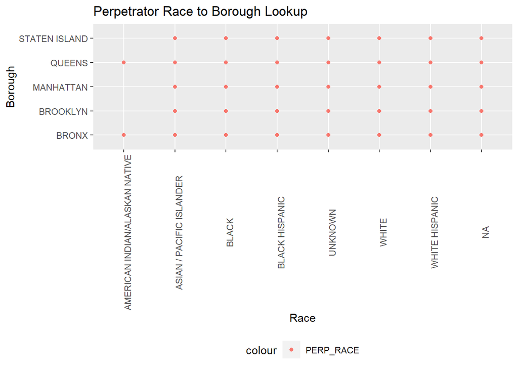

## Analysing the Data

On analyzing the first visual data, it can be observed that the data of the age group **1020** and **940** could be invalid inputs or they may be Typo while entering the data, of which we may not be sure. Also there are values with **UNKNOWN** and **NA**, where the age group of the people is not being specified. The Race also has data of **NA** and **UNKNOWN**.

From the second visual data, it can be seen that every Borough has reported data of all Race types of people being involved except for “AMERICAN INDIAN/ALASKAN NATIVE” race type, who were involved in only in Bronx and Queens Borough.

A look into the data shows that the data of **NA** and **UNKNOWN** could be valid records. So is for the **1020** and **940** age group data. Therefore, they are retained as received.

```
## # A tibble: 19,085 x 8
## # Groups:   BOROUGH [5]
##    BOROUGH  PERP_AGE_GROUP PERP_SEX PERP_RACE STATISTICAL_MURDER_~ VIC_AGE_GROUP
##    <chr>    <chr>          <chr>    <chr>     <lgl>                <chr>
##  1 QUEENS   <NA>           <NA>     <NA>      FALSE                65+
##  2 BROOKLYN <NA>           <NA>     <NA>      FALSE                18-24
##  3 BRONX    <NA>           <NA>     <NA>      FALSE                <18
##  4 QUEENS   <NA>           <NA>     <NA>      FALSE                18-24
##  5 BROOKLYN <NA>           <NA>     <NA>      FALSE                <18
##  6 BROOKLYN <NA>           <NA>     <NA>      FALSE                <18
##  7 BROOKLYN <NA>           <NA>     <NA>      FALSE                25-44
##  8 QUEENS   <NA>           <NA>     <NA>      FALSE                18-24
##  9 QUEENS   <NA>           <NA>     <NA>      FALSE                18-24
## 10 BROOKLYN <NA>           <NA>     <NA>      FALSE                <18
## # ... with 19,075 more rows, and 2 more variables: VIC_SEX <chr>,
## #   VIC_RACE <chr>
```

```
## # A tibble: 4,500 x 8
## # Groups:   BOROUGH [5]
##    BOROUGH   PERP_AGE_GROUP PERP_SEX PERP_RACE   STATISTICAL_MURD~ VIC_AGE_GROUP
##    <chr>     <chr>          <chr>    <chr>       <lgl>             <chr>
##  1 BRONX     <NA>           <NA>     <NA>        TRUE              25-44
##  2 BRONX     <NA>           <NA>     <NA>        TRUE              45-64
##  3 QUEENS    <NA>           <NA>     <NA>        TRUE              25-44
##  4 BRONX     18-24          M        BLACK       TRUE              25-44
##  5 QUEENS    <NA>           <NA>     <NA>        TRUE              18-24
##  6 QUEENS    <NA>           <NA>     <NA>        TRUE              25-44
##  7 BRONX     <NA>           <NA>     <NA>        TRUE              25-44
##  8 BROOKLYN  25-44          M        BLACK       TRUE              25-44
##  9 MANHATTAN 25-44          M        WHITE HISP~ TRUE              45-64
## 10 BROOKLYN  18-24          M        BLACK       TRUE              45-64
## # ... with 4,490 more rows, and 2 more variables: VIC_SEX <chr>, VIC_RACE <chr>
```

Following analysis is being done further down.

- Total number of people who are involved from each Borough
- Number of people of Particular Gender type is checked
- Number of Females involved from each Borough and the Race and Age Group they belong to is looked into.

Henceforth a model is prepared on the Prediction of number of females involved on Total Count

## Total Count from each Borough

```
## # A tibble: 5 x 2
##   BOROUGH       Total_Count
##   <chr>               <int>
## 1 BRONX                6701
## 2 BROOKLYN             9734
## 3 MANHATTAN            2922
## 4 QUEENS               3532
## 5 STATEN ISLAND         696
```

## Count of Particular Gender of people from each Borough

```
## # A tibble: 20 x 3
## # Groups:   BOROUGH [5]
##    BOROUGH       PERP_SEX Gender
##    <chr>         <chr>     <int>
##  1 BRONX         F            95
##  2 BRONX         M          4047
##  3 BRONX         U           396
##  4 BRONX         <NA>       2163
##  5 BROOKLYN      F           111
##  6 BROOKLYN      M          5079
##  7 BROOKLYN      U           652
##  8 BROOKLYN      <NA>       3892
##  9 MANHATTAN     F            51
## 10 MANHATTAN     M          1792
## 11 MANHATTAN     U           191
## 12 MANHATTAN     <NA>        888
## 13 QUEENS        F            66
## 14 QUEENS        M          2043
## 15 QUEENS        U           231
## 16 QUEENS        <NA>       1192
## 17 STATEN ISLAND F            12
## 18 STATEN ISLAND M           529
## 19 STATEN ISLAND U            29
## 20 STATEN ISLAND <NA>        126
```

## Count of Particular Race of people from each Borough

```
## # A tibble: 37 x 3
## # Groups:   BOROUGH [5]
##    BOROUGH  PERP_RACE                       Race
##    <chr>    <chr>                          <int>
##  1 BRONX    AMERICAN INDIAN/ALASKAN NATIVE     1
##  2 BRONX    ASIAN / PACIFIC ISLANDER          28
##  3 BRONX    BLACK                           2480
##  4 BRONX    BLACK HISPANIC                   531
##  5 BRONX    UNKNOWN                          525
##  6 BRONX    WHITE                             47
##  7 BRONX    WHITE HISPANIC                   926
##  8 BRONX    <NA>                            2163
##  9 BROOKLYN ASIAN / PACIFIC ISLANDER          33
## 10 BROOKLYN BLACK                           4362
## # ... with 27 more rows
```

## Count of Females Involved from each Borough

```
## # A tibble: 5 x 3
## # Groups:   BOROUGH [5]
##   BOROUGH       PERP_SEX Gender
##   <chr>         <chr>     <int>
## 1 BRONX         F            95
## 2 BROOKLYN      F           111
## 3 MANHATTAN     F            51
## 4 QUEENS        F            66
## 5 STATEN ISLAND F            12
```

```
## # A tibble: 5 x 4
##   BOROUGH       Total_Count PERP_SEX Gender
##   <chr>               <int> <chr>     <int>
## 1 BRONX                6701 F            95
## 2 BROOKLYN             9734 F           111
## 3 MANHATTAN            2922 F            51
## 4 QUEENS               3532 F            66
## 5 STATEN ISLAND         696 F            12
```

## Count on Females involved with regard to their Race and Age Group

```
## # A tibble: 23 x 3
## # Groups:   BOROUGH [5]
##    BOROUGH  PERP_RACE                       Race
##    <chr>    <chr>                          <int>
##  1 BRONX    AMERICAN INDIAN/ALASKAN NATIVE     1
##  2 BRONX    BLACK                             54
##  3 BRONX    BLACK HISPANIC                     8
##  4 BRONX    UNKNOWN                            3
##  5 BRONX    WHITE                              2
##  6 BRONX    WHITE HISPANIC                    27
##  7 BROOKLYN ASIAN / PACIFIC ISLANDER           1
##  8 BROOKLYN BLACK                             87
##  9 BROOKLYN BLACK HISPANIC                     5
## 10 BROOKLYN UNKNOWN                            2
## # ... with 13 more rows
```

```
## # A tibble: 23 x 3
## # Groups:   BOROUGH [5]
##    BOROUGH  PERP_AGE_GROUP Group
##    <chr>    <chr>          <int>
##  1 BRONX    <18                7
##  2 BRONX    18-24             32
##  3 BRONX    25-44             45
##  4 BRONX    45-64              4
##  5 BRONX    UNKNOWN            7
##  6 BROOKLYN <18               14
##  7 BROOKLYN 18-24             40
##  8 BROOKLYN 25-44             44
##  9 BROOKLYN 45-64              7
## 10 BROOKLYN UNKNOWN            6
## # ... with 13 more rows
```

## Count on Females involved specific to each Borough with regard to Race and Age Group

```
## # A tibble: 6 x 3
## # Groups:   BOROUGH [1]
##   BOROUGH PERP_RACE                       Race
##   <chr>   <chr>                          <int>
## 1 BRONX   AMERICAN INDIAN/ALASKAN NATIVE     1
## 2 BRONX   BLACK                             54
## 3 BRONX   BLACK HISPANIC                     8
## 4 BRONX   UNKNOWN                            3
## 5 BRONX   WHITE                              2
## 6 BRONX   WHITE HISPANIC                    27
```

```
## # A tibble: 4 x 3
## # Groups:   BOROUGH [1]
##   BOROUGH PERP_RACE       Race
##   <chr>   <chr>          <int>
## 1 QUEENS  BLACK             36
## 2 QUEENS  BLACK HISPANIC     3
## 3 QUEENS  WHITE              4
## 4 QUEENS  WHITE HISPANIC    23
```

```
## # A tibble: 3 x 3
## # Groups:   BOROUGH [1]
##   BOROUGH   PERP_RACE       Race
##   <chr>     <chr>          <int>
## 1 MANHATTAN BLACK             41
## 2 MANHATTAN BLACK HISPANIC     6
## 3 MANHATTAN WHITE HISPANIC     4
```

```
## # A tibble: 4 x 3
## # Groups:   BOROUGH [1]
##   BOROUGH       PERP_RACE       Race
##   <chr>         <chr>          <int>
## 1 STATEN ISLAND BLACK              4
## 2 STATEN ISLAND BLACK HISPANIC     1
## 3 STATEN ISLAND WHITE              6
## 4 STATEN ISLAND WHITE HISPANIC     1
```

```
## # A tibble: 6 x 3
## # Groups:   BOROUGH [1]
##   BOROUGH  PERP_RACE                 Race
##   <chr>    <chr>                    <int>
## 1 BROOKLYN ASIAN / PACIFIC ISLANDER     1
## 2 BROOKLYN BLACK                       87
## 3 BROOKLYN BLACK HISPANIC               5
## 4 BROOKLYN UNKNOWN                      2
## 5 BROOKLYN WHITE                        3
## 6 BROOKLYN WHITE HISPANIC              13
```

```
## # A tibble: 5 x 3
## # Groups:   BOROUGH [1]
##   BOROUGH PERP_AGE_GROUP Group
##   <chr>   <chr>          <int>
## 1 BRONX   <18                7
## 2 BRONX   18-24             32
## 3 BRONX   25-44             45
## 4 BRONX   45-64              4
## 5 BRONX   UNKNOWN            7
```

```
## # A tibble: 6 x 3
## # Groups:   BOROUGH [1]
##   BOROUGH PERP_AGE_GROUP Group
##   <chr>   <chr>          <int>
## 1 QUEENS  <18                6
## 2 QUEENS  18-24             36
## 3 QUEENS  25-44             17
## 4 QUEENS  45-64              3
## 5 QUEENS  65+                1
## 6 QUEENS  UNKNOWN            3
```

```
## # A tibble: 5 x 3
## # Groups:   BOROUGH [1]
##   BOROUGH   PERP_AGE_GROUP Group
##   <chr>     <chr>          <int>
## 1 MANHATTAN <18                7
## 2 MANHATTAN 18-24             14
## 3 MANHATTAN 25-44             25
## 4 MANHATTAN 45-64              3
## 5 MANHATTAN UNKNOWN            2
```

```
## # A tibble: 2 x 3
## # Groups:   BOROUGH [1]
##   BOROUGH       PERP_AGE_GROUP Group
##   <chr>         <chr>          <int>
## 1 STATEN ISLAND 18-24              4
## 2 STATEN ISLAND 25-44              8
```

```
## # A tibble: 5 x 3
## # Groups:   BOROUGH [1]
##   BOROUGH  PERP_AGE_GROUP Group
##   <chr>    <chr>          <int>
## 1 BROOKLYN <18               14
## 2 BROOKLYN 18-24             40
## 3 BROOKLYN 25-44             44
## 4 BROOKLYN 45-64              7
## 5 BROOKLYN UNKNOWN            6
```

It can be interpreted that the Female Perpetrators belonging to the race of Black and White Hispanic are mostly involved and people of Age Group’s 18-24 and 25-44, in short, 18-45 age group people are responsible for the acts.

Although other race types of people too account in the Borough’s, their numbers are comparatively less. The issue on race and their impact is a sensitive topic, but still it raises a few questions.

- Why are particular type of people responsible
- What measures could be taken to mitigate their adverse impact
- Is there any specific reasons for their act

Age group’s between 18-24 and 24-45 also would be raising the same questions.

## Modelling the Data

A model is being predicted on females involved with regard to total counts.

```
##
## Call:
## lm(formula = Gender ~ Total_Count, data = femaleGenderJoin)
##
## Residuals:
##       1       2       3       4       5
##   7.033  -9.020   2.970  11.523 -12.506
##
## Coefficients:
##              Estimate Std. Error t value Pr(>|t|)
## (Intercept) 17.150391   9.608457   1.785  0.17226
## Total_Count  0.010568   0.001692   6.244  0.00829 **
## ---
## Signif. codes:  0 '***' 0.001 '**' 0.01 '*' 0.05 '.' 0.1 ' ' 1
##
## Residual standard error: 11.96 on 3 degrees of freedom
## Multiple R-squared:  0.9286, Adjusted R-squared:  0.9047
## F-statistic: 38.99 on 1 and 3 DF,  p-value: 0.008286
```

```
## # A tibble: 5 x 5
##   BOROUGH       Total_Count PERP_SEX Gender  pred
##   <chr>               <int> <chr>     <int> <dbl>
## 1 BRONX                6701 F            95  88.0
## 2 BROOKLYN             9734 F           111 120.
## 3 MANHATTAN            2922 F            51  48.0
## 4 QUEENS               3532 F            66  54.5
## 5 STATEN ISLAND         696 F            12  24.5
```

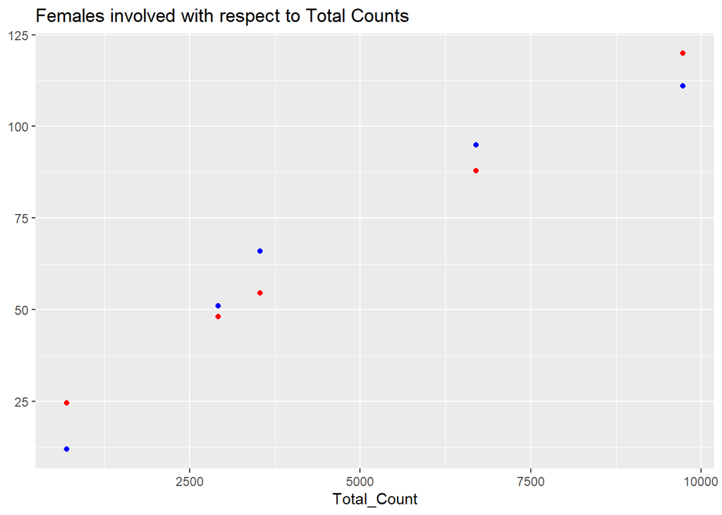

It can be observed that the predictive values in red is in line with the actual values in blue that we have for each borough of the perpetrators impact.

## Conclusion

From the analysis that is being done above on the Female Perpetrators, it can be seen that the Borough of Brooklyn is being affected highly. Staten Island looks to be far less in number compared to the other Borough’s. Though there are different race types of people who were associated and people of different age groups, it is particular race types who are engaged in them, so is a specific age group people.

There were a couple of factors that went into in the Initial Analysis,

While preparing the report, possible source of bias that was there was to identify

- the group of people who were affected
- the borough that is least affected overall

This was thought to understand on the borough of New york, if moving over there.

Then opted to look out for other options that provided a little general specific insight

- on a particular gender who have committed

The questions that have come out from this analysis are :

- would the data on other gender types also be similar
- are the same age group people related, to account for in particular borough’s

This report generation has helped me to understand the details on female perpetrators involved in NY.